# Cannibalisation in the software product lines RDD used for Windows OS

**Author:** Przemyslaw Niedziela (przemyslaw.niedziela98@gmail.com)  
**Date:** May 2024  
**TL;DR**  
This analysis aims to estimate the cannibalization effect following the launch of Windows 10 on Windows 8.1 and Windows 7, utilizing a quasi-RDD approach. This method seeks to estimate discontinuity and kinks among specific Windows OS. The data is limited to Europe, with the unit of analysis being households.  
Data is sourced from two main providers:  
(1) Eurostat - two datasets:  
- [Households - availability of computers](https://ec.europa.eu/eurostat/web/products-datasets/-/isoc_ci_cm_h)  
- [Number of households by household composition](https://data.europa.eu/data/datasets/jfpeap7gs0z4sxsrztrkig)  
(2) StatCounter - two datasets:  
- [Desktop Windows Version Market Share Europe](https://gs.statcounter.com/os-version-market-share/windows/desktop/europe#monthly-200902-202405)  
- [Operating System Market Share Europe](https://gs.statcounter.com/os-market-share/all/europe/#monthly-200902-202405)

```r
library(dplyr)
library(tidyr)
library(ggplot2)
library(strucchange)
library(zoo)
library(lmtest)
library(car)
library(pheatmap)
library(orcutt)
```

### Reading dataset

```r
eurostat_nr_computers_raw <- read.csv("eurostat_computer_numbers.csv")
eurostat_households_raw <- read.csv("eurostat_size_of_houses.csv")

os_combined <- read.csv("os_combined-eu-monthly-200902-202405.csv")
windows_combined <- read.csv("windows_version-eu-monthly-200902-202405.csv")
```

### Processing dataset

Data from Eurostat  
Processing %of households with the computer in UE

```r
nr_eu_computers <- subset(eurostat_nr_computers_raw,
                          freq.indic_is.unit.hhtyp.geo.TIME_PERIOD == 'A,H_COMP,PC_HH,TOTAL,EU27_2007')

nr_eu_computers_year <- list()
for (col in names(nr_eu_computers)[-1]) {
  nr_eu_computers_year[[sub("X", "", col)]] <- as.numeric(nr_eu_computers[1, col])
}

nr_eu_computers <- data.frame(
  TIME_PERIOD = as.numeric(names(nr_eu_computers_year)),
  OBS_VALUE_COMP = unlist(nr_eu_computers_year)
)
```

Filling %of computers missing data

```r
#missing data for 2014 and 2016 - filling with mean to keep the trend
get_mean_by_year <- function(df, year_previous, year_next) {
  mean_value <- df %>%
    filter(TIME_PERIOD %in% c(year_previous, year_next)) %>%
    summarise(mean_value = mean(OBS_VALUE_COMP, na.rm = TRUE))

  return(mean_value$mean_value)
}

nr_eu_computers <- bind_rows(nr_eu_computers,
                          data.frame(TIME_PERIOD = 2014, OBS_VALUE_COMP = get_mean_by_year(nr_eu_computers, 2013, 2015)))
nr_eu_computers <- bind_rows(nr_eu_computers,
                          data.frame(TIME_PERIOD = 2016, OBS_VALUE_COMP = get_mean_by_year(nr_eu_computers, 2015, 2017)))
```

Number of households with the computer in EU

```r
#get nr of households in UE per year
eurostat_households <- eurostat_households_raw %>%
  filter(agechild == 'TOTAL',
         n_child == 'TOTAL',
         hhcomp == 'TOTAL',
         geo == 'EU27_2020') %>%
  select(TIME_PERIOD, OBS_VALUE)

eurostat_households_with_comp <- inner_join(eurostat_households, nr_eu_computers, by = "TIME_PERIOD")

eurostat_households_with_comp <- eurostat_households_with_comp %>%
  mutate(nr_of_households_with_comp = OBS_VALUE * OBS_VALUE_COMP * 10) # Multiplied by 10 because OBS_VALUE*1000 and OBS_VALUE_COMP in %
```

Data from StatCounter

```r
get_year <- function(df) {
  df %>%
    mutate(Date = as.Date(paste0(Date, "-01"))) %>%
    mutate(year = as.integer(format(Date, "%Y")))
}

os_combined <- get_year(os_combined)
windows_combined <- get_year(windows_combined)

windows_combined <- windows_combined %>%
  filter(year <= 2017, year >= 2014)

os_real_volume_raw <- inner_join(os_combined, eurostat_households_with_comp, by = c("year" = "TIME_PERIOD"))

os_real_volume_raw <- os_real_volume_raw %>%
  mutate(households_with_windows = Windows * nr_of_households_with_comp / 100)

windows_real_volume <- os_real_volume_raw %>%
  select(Date, households_with_windows)

windows_df <- inner_join(windows_combined, windows_real_volume, by = "Date")
```

Number of households with specific Windows OS version

```r
columns_to_multiply <- c("Win7", "WinXP", "Win10", "WinVista", "Win8.1", "Win8", "Win2000")
windows_df <- windows_df %>%
  mutate(across(all_of(columns_to_multiply), ~ . * households_with_windows))
```

```r
summary(windows_df)
```

[output not shown]

```r
head(windows_df)
```

[output not shown]

### Data visualisation

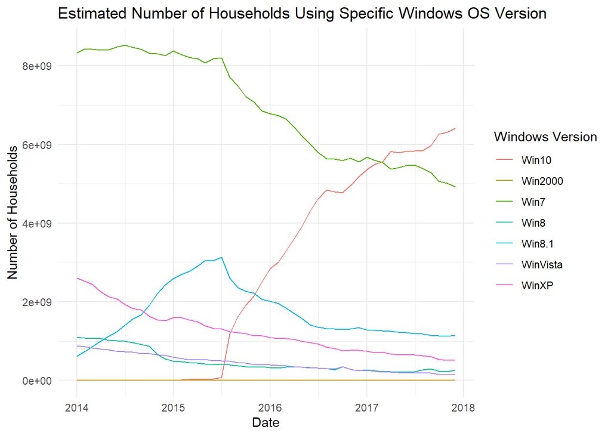

```r
df_melted <- windows_df %>%
  select(Date, all_of(columns_to_multiply)) %>%
  pivot_longer(cols = -Date, names_to = "Windows_Version", values_to = "Value")

line_plot <- ggplot(df_melted, aes(x = Date,
                                   y = Value,
                                   color = Windows_Version,
                                   group = Windows_Version)) +
  geom_line() +
  labs(title = "Estimated Number of Households Using Specific Windows OS Version",
       x = "Date",
       y = "Number of Households",
       color = "Windows Version") +
  theme_minimal()

ggsave("nr_of_households.png", line_plot, width = 10, height = 4, units = "in")

print(line_plot)
```

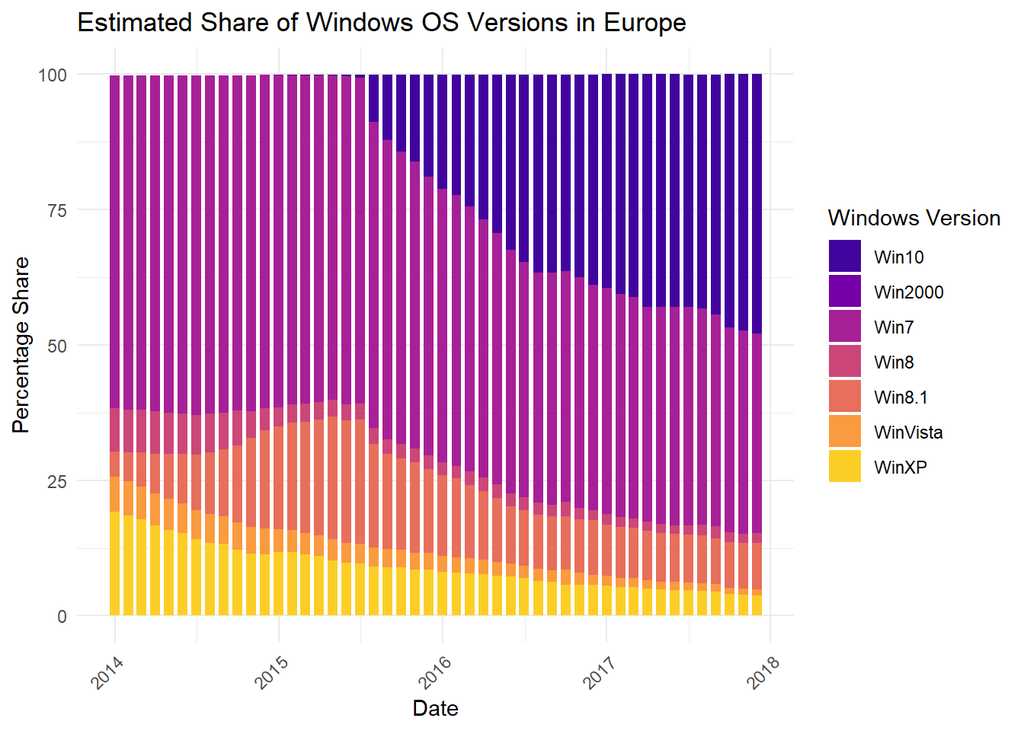

```r
df_melted <- windows_combined %>%
  select(Date, all_of(columns_to_multiply)) %>%
  pivot_longer(cols = -Date, names_to = "Windows_Version", values_to = "Value")

bar_plot <- ggplot(df_melted, aes(x = Date, y = Value, fill = Windows_Version)) +
  geom_col(position = "stack", width = 22) +
  labs(title = "Estimated Share of Windows OS Versions in Europe",
       x = "Date",
       y = "Percentage Share",
       fill = "Windows Version") +
  theme_minimal() +
  scale_fill_viridis_d(option = "C", begin = 0.1, end = 0.9) +
  theme(axis.text.x = element_text(angle = 45, hjust = 1),
        legend.position = "right")

print(bar_plot)
```

### Checking structural breakpoints

Chow test for structural breakpoint after the Launch of Windows 10

```r
WINDOW_10_LAUNCH <- '2015-07-01'

windows_df <- windows_df %>%
  mutate(x = row_number())

point <- windows_df %>%
  filter(Date == WINDOW_10_LAUNCH)

test_statistic <- vector("numeric", length(columns_to_multiply))
p_value <- vector("numeric", length(columns_to_multiply))


for (i in seq_along(columns_to_multiply)) {
  col <- columns_to_multiply[i]
  test <- sctest(windows_df[[col]] ~ windows_df$x, type = "Chow", point = point$x)
  test_statistic[i] <- test$stat
  p_value[i] <- test$p.value
}

chow_test_structural_point <- data.frame(
  Column = columns_to_multiply,
  F_Statistic = test_statistic,
  P_Value = p_value,
  weighted_test_static = test_statistic * unlist(point[columns_to_multiply][1, ])
)

chow_test_structural_point <- chow_test_structural_point %>%
  filter(Column != 'Win10') %>%
  arrange(desc(weighted_test_static))

print(chow_test_structural_point)
```

```
##            Column F_Statistic      P_Value weighted_test_static
## Win8.1     Win8.1 334.2869046 0.000000e+00         1.045269e+12
## Win7         Win7  39.0543664 1.768199e-10         3.201994e+11
## WinXP       WinXP  69.5556580 2.375877e-14         9.101626e+10
## Win8         Win8 135.3705900 0.000000e+00         5.424840e+10
## WinVista WinVista  94.9259970 1.110223e-16         4.709793e+10
## Win2000   Win2000   0.4241288 6.569862e-01         1.156227e+06
```

### Checking correlations

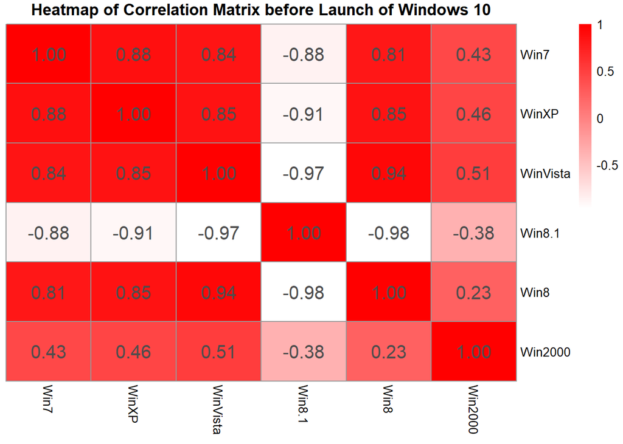

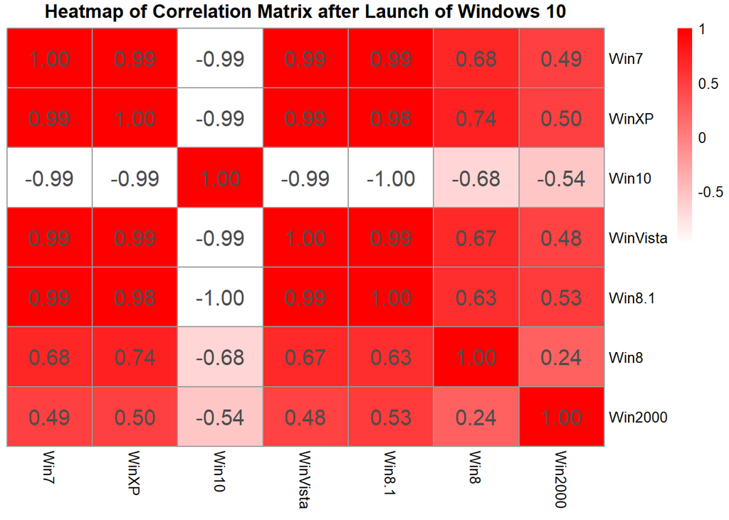

```r
products_df_before <- windows_df %>%
  filter((x >= point$x - 11) & (x < point$x + 1)) %>%
  select(all_of(columns_to_multiply))

products_df_before <- products_df_before[, !names(products_df_before) %in% "Win10"]

products_df_after <- windows_df %>%
  filter((x > point$x + 1) & (x < point$x + 13)) %>%
  select(all_of(columns_to_multiply))

data_list <- list(before = products_df_before, after = products_df_after)

for (name in names(data_list)) {
  product_df <- data_list[[name]]
  correlation_matrix <- cor(product_df)

  pheatmap(correlation_matrix,
           display_numbers = TRUE,
           color = colorRampPalette(c('white', 'red'))(100),
           cluster_rows = FALSE,
           cluster_cols = FALSE,
           fontsize_number = 15,
           main = sprintf("Heatmap of Correlation Matrix %s Launch of Windows 10", name))
}
```

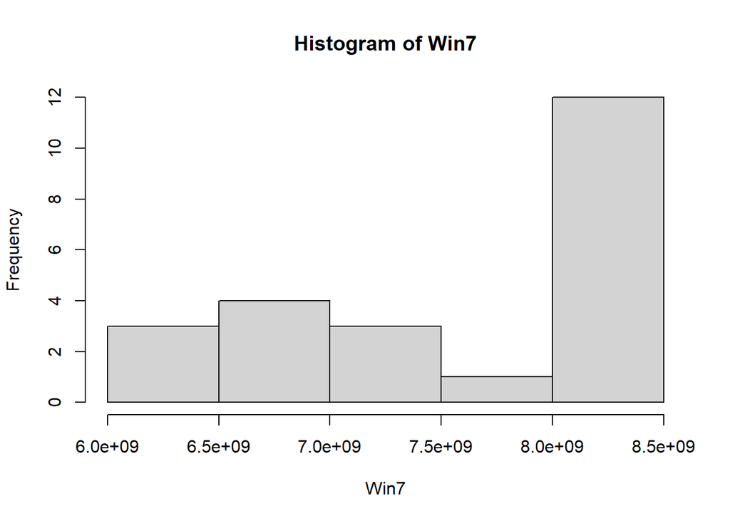

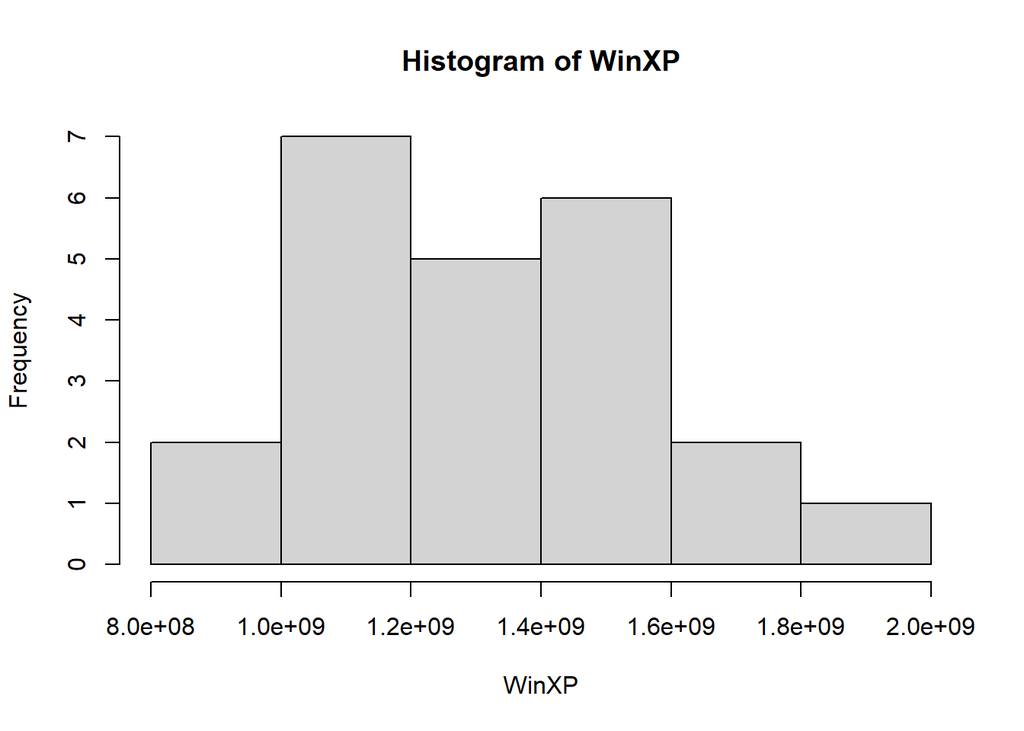

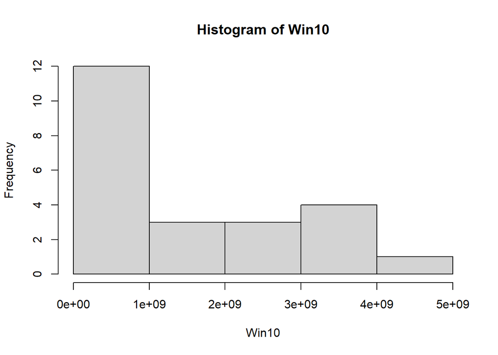

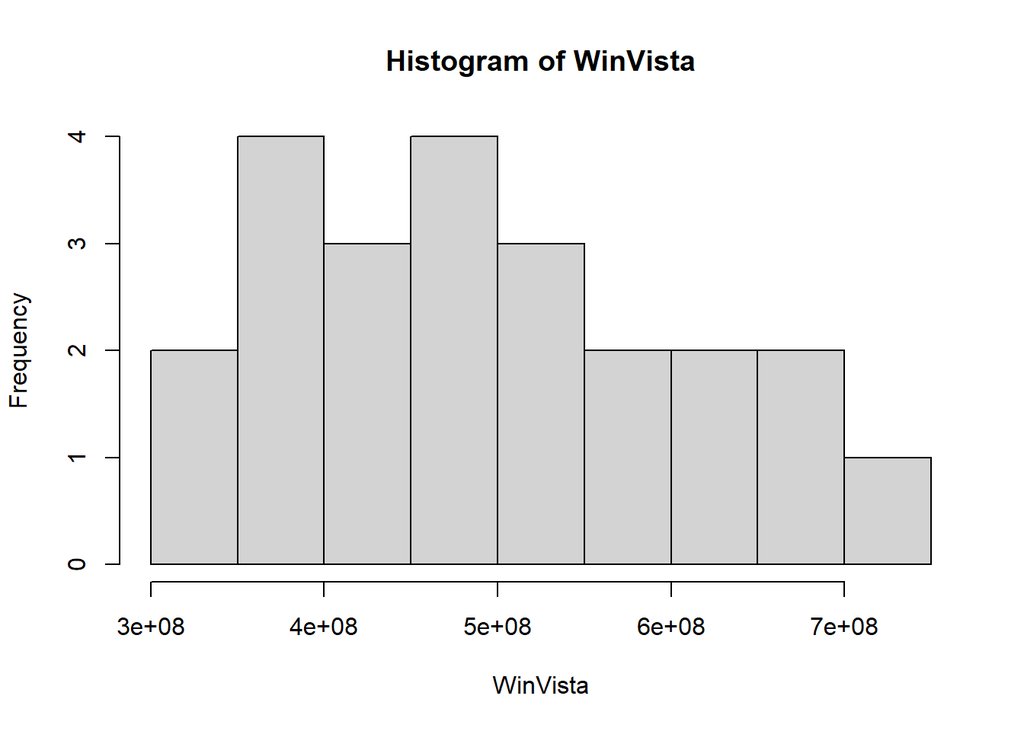

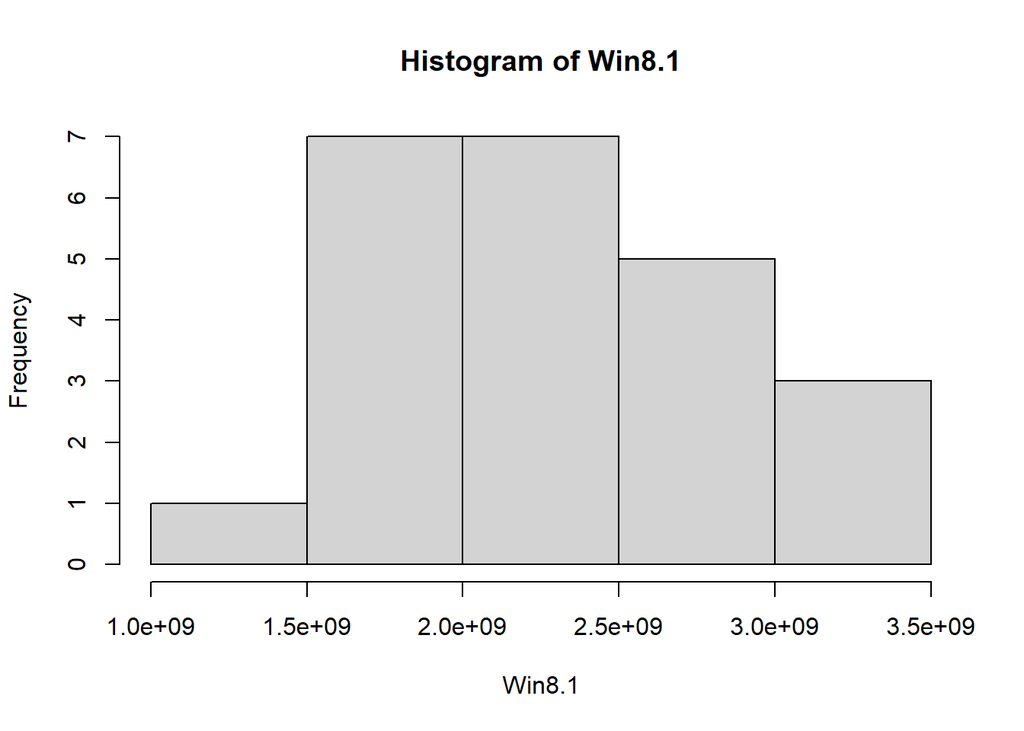

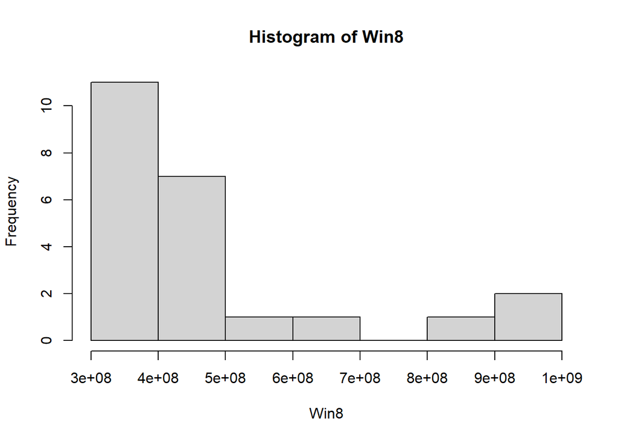

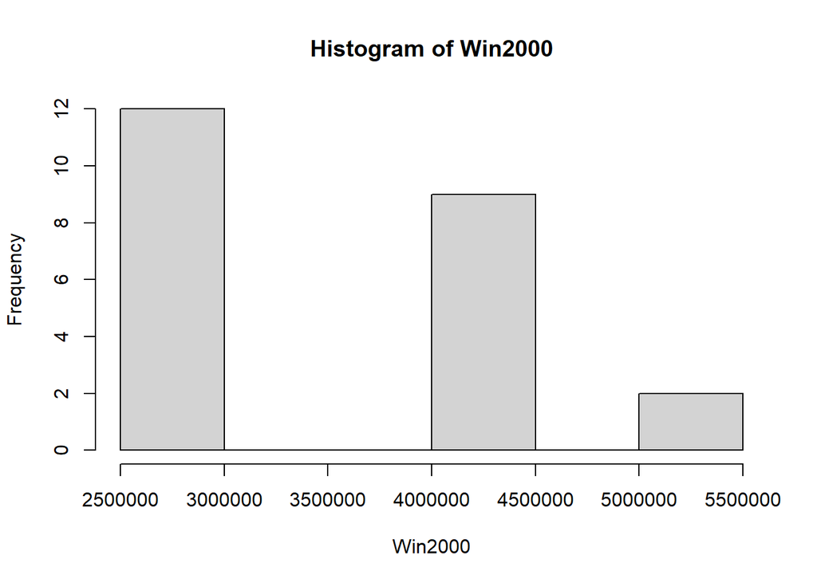

```r
for (col in columns_to_multiply){
  df_hist <- windows_df %>%
    filter((x >= point$x - 11) & (x < point$x + 12))

  hist(df_hist[[col]], main = sprintf("Histogram of %s", col), xlab = col)
}
```

### Modeling effect using regression with discontinuity

```r
evaluate_model <- function(model) {
  print(summary(model))
  print(vif(model))
  print(bptest(model))
  print(dwtest(model))
  plot(model, which = 1)
}

show_predictions <- function(df, point_break, model) {
  df$fit <- predict(model)

  beta_2 <- coef(model)["D"]
  beta_3 <- coef(model)["K"]

  print(sprintf("beta2: %s", beta_2))
  print(sprintf("beta3: %s", beta_3))

  df$predicted_effect <- ifelse(df$x >= point_break, beta_2 + beta_3 * (df$x - point_break), NA)
  df$x_visual <- df$x - df$x[1] - 11.5

  graph <- ggplot(df, aes(x = x_visual, y = y)) +
    geom_point() +
    geom_line(aes(y = ifelse(df$x >= point_break, df$fit, NA)), color = 'gray', size = 1) +
    geom_line(aes(y = ifelse(df$x < point_break, df$fit, NA)), color = 'gray', size = 1) +
    geom_line(aes(y = ifelse(df$x >= point_break, df$fit - df$predicted_effect, NA)), color = 'gray', linetype = "dashed", size = 1) +
    geom_vline(xintercept = 0, linetype = "dashed", color = "red") +
    ggtitle(sprintf("Users of %s with RDD", col)) +
    xlab("Months after Win10 launch") +
    ylab(sprintf("Users %s", col)) +
    theme_minimal()

  plot(graph)
  return(df)
}
```

Windows7 <> Windows10

```r
result_list <- list()

col <- "Win7"
point_break <- point$x + 1

df <- data.frame(
  x = windows_df$x,
  y = windows_df[[col]],
  t = windows_df$households_with_windows,
  wv = windows_df$WinVista,
  wx = windows_df$WinXP,
  w2k = windows_df$Win2000,
  w7 = windows_df$Win7
)

df <- df[(point_break - 12):(point_break + 12),]

df$D <- ifelse(df$x >= point_break, 1, 0)
df$K <- ifelse(df$x >= point_break, df$x - point_break, 0)
df$rest <- df$wv + df$wx + df$w2k

model <- lm(y ~ D + K + t + rest, data = df)
evaluate_model(model)
```

```
##
## Call:
## lm(formula = y ~ D + K + t + rest, data = df)
##
## Residuals:
##       Min        1Q    Median        3Q       Max
## -80863917 -37385279   3460562  26814719  84368485
##
## Coefficients:
##               Estimate Std. Error t value Pr(>|t|)
## (Intercept) -9.866e+07  1.560e+09  -0.063 0.950204
## D           -4.431e+08  3.886e+07 -11.402 3.34e-10 ***
## K           -1.329e+08  4.830e+06 -27.524  < 2e-16 ***
## t            5.459e+01  1.145e+01   4.767 0.000118 ***
## rest         4.591e-01  6.190e-02   7.418 3.67e-07 ***
## ---
## Signif. codes:  0 '***' 0.001 '**' 0.01 '*' 0.05 '.' 0.1 ' ' 1
##
## Residual standard error: 48020000 on 20 degrees of freedom
## Multiple R-squared:  0.9978, Adjusted R-squared:  0.9974
## F-statistic:  2287 on 4 and 20 DF,  p-value: < 2.2e-16
##
##        D        K        t     rest
## 4.086639 4.113818 1.593844 6.455194
##
##  studentized Breusch-Pagan test
##
## data:  model
## BP = 7.7524, df = 4, p-value = 0.1011
##
##
##  Durbin-Watson test
##
## data:  model
## DW = 1.4422, p-value = 0.01103
## alternative hypothesis: true autocorrelation is greater than 0
```

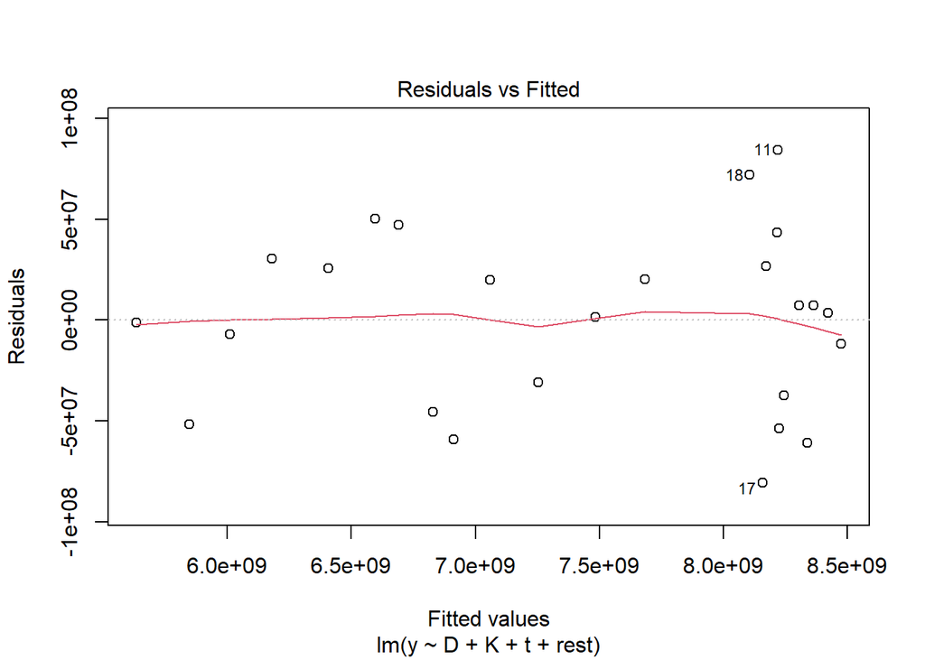

```r
#Cochrane-Orcutt transformation
co_model <- cochrane.orcutt(model)
summary(co_model)
```

```
## Call:
## lm(formula = y ~ D + K + t + rest, data = df)
##
##                Estimate  Std. Error t value  Pr(>|t|)
## (Intercept)  3.8312e+08  1.7345e+09   0.221 0.8275403
## D           -4.5297e+08  4.8938e+07  -9.256 1.801e-08 ***
## K           -1.3466e+08  7.1271e+06 -18.894 8.936e-14 ***
## t            5.1420e+01  1.2706e+01   4.047 0.0006885 ***
## rest         4.3441e-01  1.0386e-01   4.183 0.0005048 ***
## ---
## Signif. codes:  0 '***' 0.001 '**' 0.01 '*' 0.05 '.' 0.1 ' ' 1
##
## Residual standard error: 47124321 on 19 degrees of freedom
## Multiple R-squared:  0.9959 ,  Adjusted R-squared:  0.995
## F-statistic: 1140.3 on 4 and 19 DF,  p-value: < 2.451e-22
##
## Durbin-Watson statistic
## (original):    1.44216 , p-value: 1.103e-02
## (transformed): 1.91005 , p-value: 1.628e-01
```

```r
df <- show_predictions(df, point_break, co_model)
```

```
## [1] "beta2: -452971970.708741"
## [1] "beta3: -134658299.480284"
```

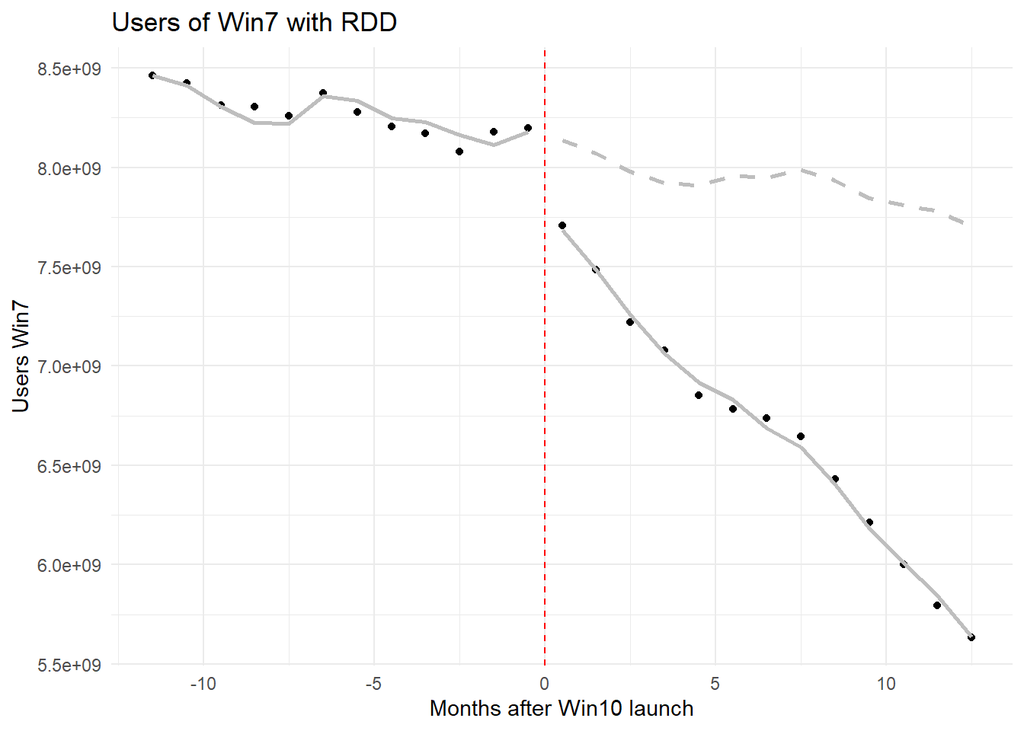

```r
predictions_w7 <- df$predicted_effect
df$model <- col
result_list[[col]] <- df
```

Windows8.1 <> Windows10

```r
col <- "Win8.1"
predictions_w7[is.na(predictions_w7)] <- 0

point_break <- point$x + 1

df <- data.frame(
  x = windows_df$x,
  y = windows_df[[col]],
  t = windows_df$households_with_windows,
  wv = windows_df$WinVista,
  wx = windows_df$WinXP,
  w2k = windows_df$Win2000,
  w7 = windows_df$Win7,
  w8 = windows_df$Win8
)

df <- df[(point_break - 12):(point_break + 12),]

df$D <- ifelse(df$x >= point_break, 1, 0)
df$K <- ifelse(df$x >= point_break, df$x - point_break, 0)
df$rest <- df$wx + df$wv + df$w2k + df$w7 - predictions_w7 + df$w8

model <- lm(y ~ D + K + t + rest, data = df)
evaluate_model(model)
```

```
##
## Call:
## lm(formula = y ~ D + K + t + rest, data = df)
##
## Residuals:
##       Min        1Q    Median        3Q       Max
## -88912930 -28502147   8999271  34745295  64627111
##
## Coefficients:
##               Estimate Std. Error t value Pr(>|t|)
## (Intercept) -2.219e+09  1.490e+09  -1.489    0.152
## D           -7.610e+08  3.435e+07 -22.151 1.52e-15 ***
## K           -1.608e+08  4.185e+06 -38.431  < 2e-16 ***
## t            1.137e+02  1.089e+01  10.441 1.52e-09 ***
## rest        -9.710e-01  2.517e-02 -38.575  < 2e-16 ***
## ---
## Signif. codes:  0 '***' 0.001 '**' 0.01 '*' 0.05 '.' 0.1 ' ' 1
##
## Residual standard error: 45670000 on 20 degrees of freedom
## Multiple R-squared:  0.9945, Adjusted R-squared:  0.9933
## F-statistic: 896.6 on 4 and 20 DF,  p-value: < 2.2e-16
##
##        D        K        t     rest
## 3.530344 3.413621 1.593702 4.428111
##
##  studentized Breusch-Pagan test
##
## data:  model
## BP = 11.64, df = 4, p-value = 0.02024
##
##
##  Durbin-Watson test
##
## data:  model
## DW = 2.2265, p-value = 0.399
## alternative hypothesis: true autocorrelation is greater than 0
```

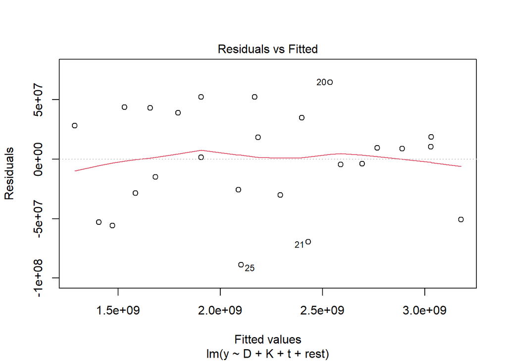

```r
#Cochrane-Orcutt transformation
co_model <- cochrane.orcutt(model)
summary(co_model)
```

```
## Call:
## lm(formula = y ~ D + K + t + rest, data = df)
##
##                Estimate  Std. Error t value  Pr(>|t|)
## (Intercept) -2.7628e+09  1.3939e+09  -1.982   0.06213 .
## D           -7.6180e+08  3.1628e+07 -24.086 1.059e-15 ***
## K           -1.5937e+08  3.8332e+06 -41.576 < 2.2e-16 ***
## t            1.1714e+02  1.0005e+01  11.708 3.921e-10 ***
## rest        -9.6319e-01  2.5745e-02 -37.413 < 2.2e-16 ***
## ---
## Signif. codes:  0 '***' 0.001 '**' 0.01 '*' 0.05 '.' 0.1 ' ' 1
##
## Residual standard error: 45612302 on 19 degrees of freedom
## Multiple R-squared:  0.9958 ,  Adjusted R-squared:  0.995
## F-statistic: 1135.1 on 4 and 19 DF,  p-value: < 2.558e-22
##
## Durbin-Watson statistic
## (original):    2.22647 , p-value: 3.99e-01
## (transformed): 2.15898 , p-value: 3.154e-01
```

```r
df <- show_predictions(df, point_break, co_model)
```

```
## [1] "beta2: -761804240.14217"
## [1] "beta3: -159368298.127872"
```

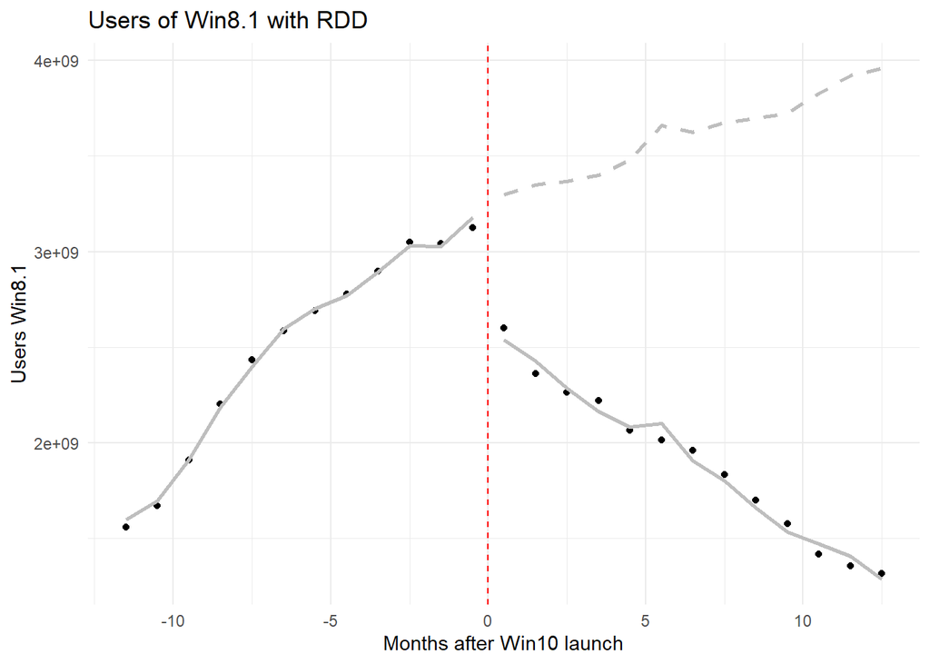

```r
df$model <- col

result_list[[col]] <- df
```

Merging predictions

```r
expand_predictions <- function(all_predictions, df, model_name) {
  pred_df <- all_predictions %>%
    filter(model == model_name) %>%
    select(x, predicted_effect) %>%
    mutate(predicted_effect = abs(predicted_effect))

  df <- inner_join(df, pred_df, by = "x")
  colnames(df)[colnames(df) == 'predicted_effect'] <- sprintf('predicted_effect_%s', sub('.1', '', model_name))

  return(df)
}

all_predictions <- bind_rows(result_list)

windows_all_predictions <- expand_predictions(all_predictions, windows_df, 'Win8.1')
windows_all_predictions <- expand_predictions(all_predictions, windows_all_predictions, 'Win7')

windows_all_predictions <- windows_all_predictions %>%
  mutate(windows_new_users = Win10 - predicted_effect_Win8 - predicted_effect_Win7) %>%
  mutate(windows_new_users = ifelse(windows_new_users < 0, 0, windows_new_users))
```

Showing Predictions

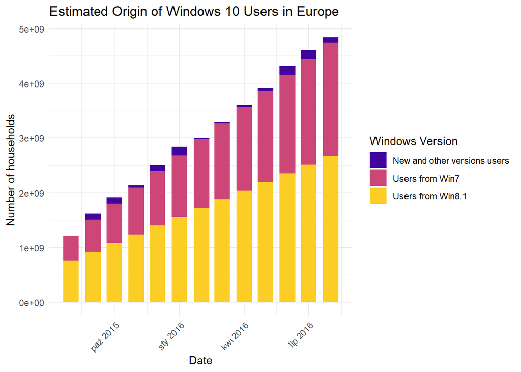

```r
legend_names <- c("New and other versions users", "Users from Win8.1", "Users from Win7")

df_melted <- windows_all_predictions %>%
  select(Date, all_of(c("windows_new_users", "predicted_effect_Win8", "predicted_effect_Win7"))) %>%
  rename(
    !!legend_names[1] := windows_new_users,
    !!legend_names[2] := predicted_effect_Win8,
    !!legend_names[3] := predicted_effect_Win7
  ) %>%
  pivot_longer(cols = -Date, names_to = "Windows_Version", values_to = "Value")

plot <- ggplot(df_melted, aes(x = Date, y = Value, fill = Windows_Version)) +
  geom_col(position = "stack", width = 22) +
  labs(
    title = "Estimated Origin of Windows 10 Users in Europe",
    x = "Date",
    y = "Number of households",
    fill = "Windows Version"
  ) +
  theme_minimal() +
  scale_fill_viridis_d(option = "C", begin = 0.1, end = 0.9) +
  theme(
    axis.text.x = element_text(angle = 45, hjust = 1),
    legend.position = "right"
  )
plot(plot)
```

```r
df_new_users_vs_households_with_windows <- data.frame(
  rolling_difference_total_windows_households = c(0, diff(windows_all_predictions$households_with_windows)),
  new_users_and_other_windows = windows_all_predictions$windows_new_users
) %>%
  filter(new_users_and_other_windows > 0)

print(df_new_users_vs_households_with_windows)
```

```
##    rolling_difference_total_windows_households new_users_and_other_windows
## 1                                   -862597.58                   111517271
## 2                                  -1427206.91                   108464129
## 3                                   -486191.36                    39705517
## 4                                   -125468.74                   116983578
## 5                                   1422057.80                   159626924
## 6                                     95600.05                    21340463
## 7                                    844467.15                    22907482
## 8                                   -701067.07                    35821430
## 9                                  -1099400.63                    55204793
## 10                                  -286800.16                   160272572
## 11                                  -207133.45                   162359814
## 12                                  -748867.09                    99776328
```